# Solar radiation, Fraunhofer lines, Earth lines, Daylight basis

#sec-lightfield-properties

The solar radiation has a fairly stable spectrum, with lines that represent where atoms in the surface of the sun absorb (Fraunhofer). As the radiation reaches the surface of the earth, it is also absorbed and scattered by particles and water in the atmosphere. Finally, the length of the trip through the atmosphere depends on the time of day, as the Earth rotates.

These graphs illustrate some of the standards of solar radiation, including a model of the skylight illumination at the Earth's surface.

## Solar radiation

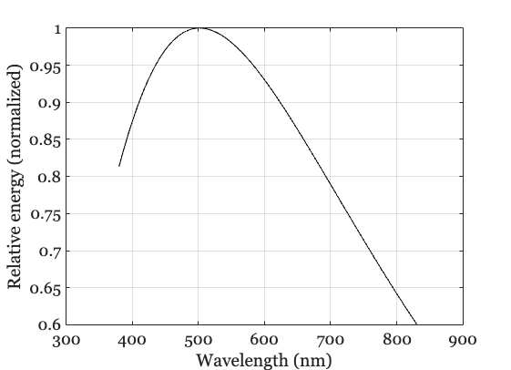

```matlab
wave = 380:830;
[solar,~,comment] = ieReadSpectra('solarSpectrum',wave);

ieFigure;
plot(wave,solar,'k-');
grid on;
xlabel('Wavelength (nm)'); ylabel('Relative energy (normalized)');
```

## Some of the Fraunhofer lines

From the sun and Earth's atmosphere.

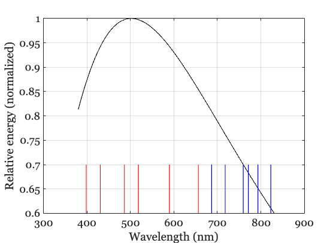

```matlab
allLines = comment{4};

% These are some examples for plotting.
fSelectSolar = comment{5};
fSelectEarth = comment{6};

solarLines = allLines(fSelectSolar(:),:);
solarLines = cell2mat(solarLines(:,3))';

earthLines = allLines(fSelectEarth(:),:);
earthLines = cell2mat(earthLines(:,3))';

hold on;
ylim = get(gca,'ylim');
x = earthLines;
for ii=1:numel(x)
    line([x(ii),x(ii)],[ylim(1),ylim(1)+0.1],'Color','b');
end

x = solarLines;
for ii=1:numel(x)
    line([x(ii),x(ii)],[ylim(1),ylim(1)+0.1],'Color','r');
end

grid on;
xlabel('Wavelength (nm)'); ylabel('Relative energy (normalized)');
```

## The Judd Macadam Wyszecki Daylight model

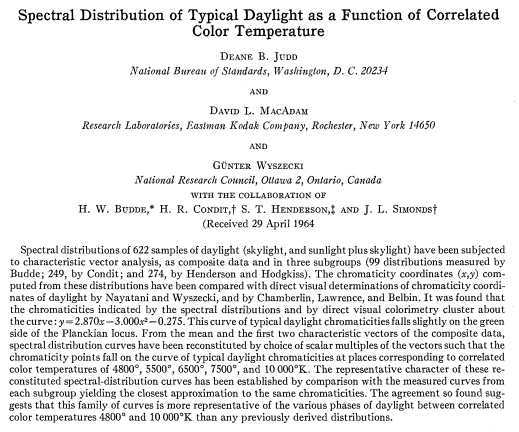

%

This group and several others measured the spectral distributions of irradiance at the Earth's surface. The found a two-dimensional linear model that described a large percentage of the variance of their (normalized) data (mean plus two basis vectors). These have been confirmed by other authors, and here is the models that has been adopted as a CIE standard.

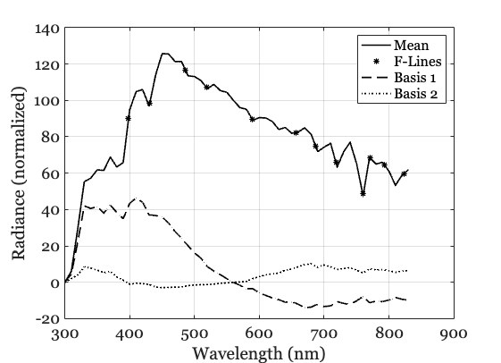

```matlab
[dayBasis,wave] = ieReadSpectra('cieDaylightBasis');

ieFigure;
sym = {'k-','k--','k:'};
for ii=1:3
    plot(wave,dayBasis(:,ii),sym{ii},'LineWidth',1.5); hold on;
    if ii==1
        tmp = interp1(wave,dayBasis(:,ii),[earthLines, solarLines]);
        plot([earthLines, solarLines],tmp,'k*');
    end
end
% xaxisLine(gca,0,'-.');
grid on;
legend({'Mean','F-Lines','Basis 1','Basis 2'});
xlabel('Wavelength (nm)'); ylabel('Radiance (normalized)');
```

## Stanford sunlight

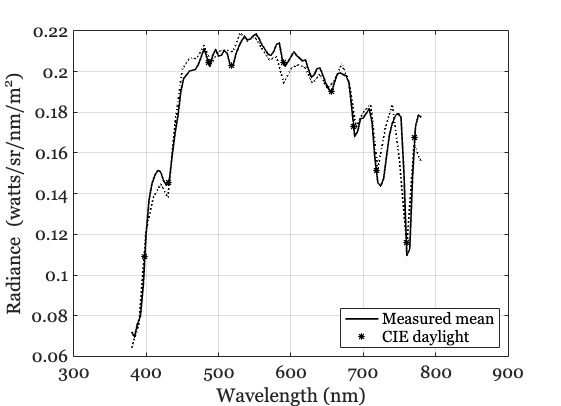

```matlab
wave = 380:780;

spd = ieReadSpectra('daylightSpectra',wave);
spdM = mean(spd,2);

ieFigure;
plot(wave,spdM,'k-','LineWidth',1.5); hold on;

% {
tmp = interp1(wave,spdM,[earthLines, solarLines]);
plot([earthLines, solarLines],tmp,'k*');
%}

dayBasis = ieReadSpectra('cieDaylightBasis',wave);
wgts = pinv(dayBasis)*spdM;
pred = dayBasis*wgts;
plot(wave,pred,'k:','LineWidth',1.5);

grid on;
set(gca,'xlim',[300 900]);
xlabel('Wavelength (nm)'); ylabel('Radiance (watts/sr/nm/m^2)');
legend({'Measured mean','CIE daylight'},'location','southeast');
```